# Final Project: Predicting IMDb Ratings for Scooby-Doo Movies

```r
print(summary(monster_weighted_model))
```

```
##
## Call:
## lm(formula = imdb ~ monster_amount_cat, data = scoobydoo_filtered,
##     weights = weights_monster)
##
## Weighted Residuals:
##      Min       1Q   Median       3Q      Max
## -0.67358 -0.04922  0.02767  0.07492  0.42339
##
## Coefficients:
##                      Estimate Std. Error t value Pr(>|t|)
## (Intercept)            6.1984     0.1043  59.408  < 2e-16 ***
## monster_amount_cat.L   0.9958     0.1807   5.511  2.3e-06 ***
## monster_amount_cat.Q  -0.3125     0.1807  -1.729   0.0915 .
## ---
## Signif. codes:  0 '***' 0.001 '**' 0.01 '*' 0.05 '.' 0.1 ' ' 1
##
## Residual standard error: 0.1807 on 40 degrees of freedom
## Multiple R-squared:  0.4547, Adjusted R-squared:  0.4274
## F-statistic: 16.68 on 2 and 40 DF,  p-value: 5.401e-06
```

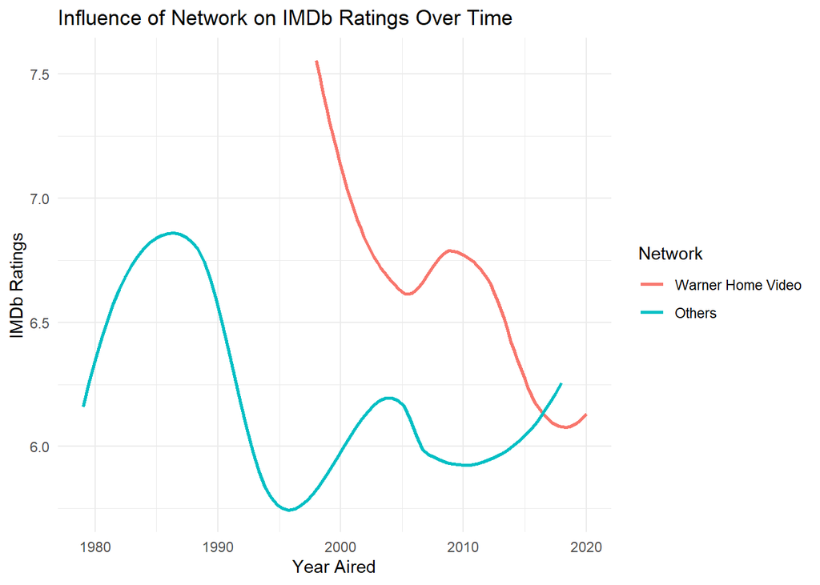

```r
# Plot1 IMDb Ratings Over Time by Network

network_data <- scoobydoo_filtered %>%
  filter(network %in% c("Warner Home Video", "Others"))

ggplot(network_data, aes(x = year_aired, y = imdb, color = network)) +
  geom_line(stat = "smooth", method = "loess", se = FALSE, size = 1) +
  labs(
    title = "Influence of Network on IMDb Ratings Over Time",
    x = "Year Aired",
    y = "IMDb Ratings",
    color = "Network"
  ) +
  theme_minimal()
```

[figure not shown]

```r
# Plot 2. Effect of monster presence on IMDb ratings over time with number of observations included to address the small amount of observations in "no monsters" category.

filtered_data <- scoobydoo_filtered %>%
  filter(monster_amount_cat %in% c("Few monsters", "No monsters", "A lot of monsters"))


filtered_data_summary <- filtered_data %>%
  group_by(year_aired, monster_amount_cat) %>%
  summarise(
    avg_imdb = mean(imdb, na.rm = TRUE),
    count = n()
  ) %>%
  ungroup()
ggplot(filtered_data_summary, aes(x = year_aired, y = avg_imdb, color = monster_amount_cat, size = count)) +
  geom_point() +
  geom_line(size = 1) +
  scale_size_continuous(range = c(1, 5), name = "Number of Observations") + # Adjust point size
  labs(
    title = "Effect of Monster Presence on IMDb Ratings Over Time",
    x = "Year Aired",
    y = "Average IMDb Ratings",
    color = "Monster Amount"
  ) +
  theme_minimal()
```

Results and discussion. In the simple model, which includes only year_aired and network as predictors, both variables are statistically significant. Year_aired (β = -0.035, p = 0.005) is a significant negative predictor of IMDb ratings, indicating that ratings tend to decrease over time. Network (Others) (β = -0.662, p = 0.020) suggests that movies produced by networks other than “Warner Home Video” are associated with lower IMDb ratings. The complex model incorporates an additional predictor, monster_amount_cat, which significantly improves the explanatory power of the model. Year_aired remains a significant negative predictor (β = -0.047, p < 0.001). Network (Others) continues to show a significant negative association (β = -0.547, p = 0.025). Monster_amount_cat is also a highly significant predictor, with a positive linear trend (β = 1.007, p < 0.001) and a significant quadratic effect (β = -0.666, p = 0.001). This indicates that movies with some monsters (e.g., “Few monsters”) receive higher ratings, but the effect is more mixed when the number of monsters becomes excessive. The comparison of model fit statistics highlights the superiority of the complex model. The weighted regression for monster_amount_cat further supports these findings. After adjusting for differences in category sizes, the linear effect remains highly significant (β = 0.996, p < 0.001), reinforcing the importance of monster presence in influencing ratings. However the quadratic term (β = -0.312, p = 0.092) is no longer significant, pointing out that solid conclusions can’t be made about the increasing number of monsters and IMDb ratings based on these results.

Discussion. While the complex model seems to provide a better fit, we cannot draw any definitive conclusions from this data yet. For now, we can only suggest that having no monsters seems to be a poor choice for Scooby-Doo movies, especially since it consistently resulted in lower ratings over the years, never even reaching 7. Additionally, it appears that having a few monsters in the cartoons is the safest approach, but further analysis is needed. We can also observe that the movies are losing popularity over time, and the Warner Home Video network seems to be more successful.